# Assignment 2: Cross-Validation and K-Nearest-Neighbor

Author

Solution by Dr. Theobold

# The Data

````markdown
```{r}
#| label: packages
#| message: false
#| warning: false

library(tidyverse)
library(tidymodels)
library(ggridges)

set.seed(3849)
```
````

The dataset we will use for this assignment pertains to the [World Happiness Report](https://worldhappiness.report/). The following dataset contains information about six measurements of well-being in a country:

- The Gross Domestic Product (GDP) per capita *(dollars; log scale)*
- The life expectancy at birth of a healthy citizen *(years)*
- The social support of friends and family *(scale of 0-1, based on surveys)*
- The freedom to make life choices in the society *(scale of 0-1, based on surveys)*
- The generosity of the society *(scale of -1 to 1, based on surveys)*
- Perception of corruption in government of the country *(scale of 0-1, based on surveys)*

The data also records the year of measurement and the region of the country.

Although it is not a formal question on this assignment, you should begin by reading in the dataset and briefly exploring and summarizing the data, and by adjusting any variables that need cleaning.

````markdown
```{r}
#| message: false
#| label: data-read

whr <- read_csv(here::here("02-CV-KNN",
                           "Assignment",
                           "data",
                           "whr_clean.csv")
                )
```
````

````markdown
```{r}
#| label: data-clean

whr <- whr %>%
  mutate(
    regional_indicator = factor(regional_indicator),
    year_f = factor(year)
  )
```
````

# Happiness Scores

The World Happiness Report uses their own, privately-determined formula to combine the six measures of life quality into a “happiness score”. The dataset also contains this score, on a scale from 1 to 10.

*Hint: The following two questions require you to fit only one model each.*

## Part 1: Happiness Over Time

1. Is the happiness in the world changing linearly over time? Fit a simple linear model and interpret the results to address this question.

````markdown
```{r}
#| label: year-lm

lin_mod <- linear_reg() %>%
  set_mode("regression") %>%
  set_engine("lm")

whr_fit <- lin_mod %>%
  fit(happiness_score ~ year, data = whr)

whr_fit$fit %>%
  broom::tidy()
```
````

```
# A tibble: 2 × 5
  term        estimate std.error statistic p.value
  <chr>          <dbl>     <dbl>     <dbl>   <dbl>
1 (Intercept)  0.742    13.2        0.0563   0.955
2 year         0.00234   0.00655    0.357    0.721
```

No, the linear regression with `year` as a predictor has a large p-value, indicating there is little to no evidence of a linear relationship between happiness and time.

2. Was the happiness score approximately the same in all the years? Convert `year` to a factor variable, and fit a simple linear model to address this question.

````markdown
```{r}
#| label: year-anova

whr_fit_2 <- lin_mod %>%
  fit(happiness_score ~ year_f, data = whr)

whr_fit_2$fit %>%
  broom::tidy()
```
````

```
# A tibble: 15 × 5
   term        estimate std.error statistic   p.value
   <chr>          <dbl>     <dbl>     <dbl>     <dbl>
 1 (Intercept)    6.45      0.214     30.1  8.34e-162
 2 year_f2006    -1.25      0.245     -5.10 3.69e-  7
 3 year_f2007    -1.03      0.241     -4.26 2.13e-  5
 4 year_f2008    -1.03      0.239     -4.29 1.85e-  5
 5 year_f2009    -0.989     0.239     -4.14 3.55e-  5
 6 year_f2010    -0.949     0.237     -4.01 6.27e-  5
 7 year_f2011    -1.02      0.233     -4.38 1.26e-  5
 8 year_f2012    -1.00      0.234     -4.28 1.92e-  5
 9 year_f2013    -1.05      0.235     -4.48 7.85e-  6
10 year_f2014    -1.06      0.234     -4.53 6.39e-  6
11 year_f2015    -1.04      0.234     -4.46 8.81e-  6
12 year_f2016    -1.05      0.234     -4.47 8.14e-  6
13 year_f2017    -0.986     0.233     -4.23 2.50e-  5
14 year_f2018    -0.947     0.234     -4.05 5.41e-  5
15 year_f2019    -0.875     0.234     -3.75 1.85e-  4
```

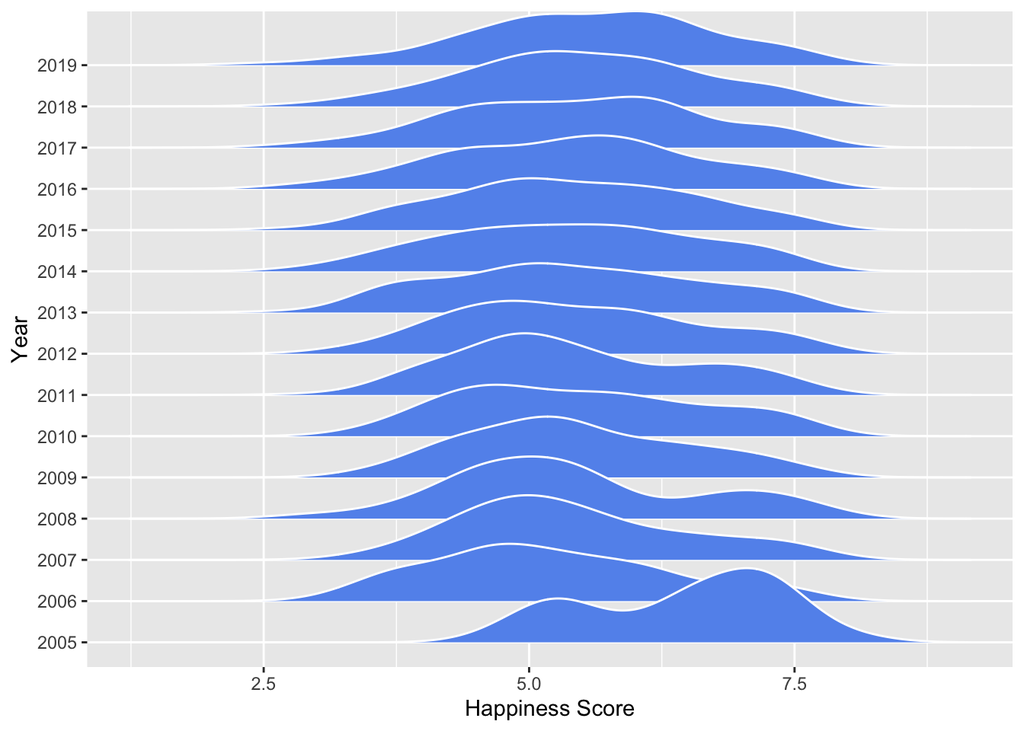

````markdown
```{r}
#| message: false
#| label: year-density

whr %>%
  ggplot(mapping = aes(y = year_f, x = happiness_score)) +
  geom_density_ridges(fill = "cornflowerblue",
                      color = "white") +
  labs(y = "Year", x = "Happiness Score")
```
````

## Part 2: Happiness Equation

3. How is each of the six measures of life quality weighted in calculating this score? Fit a model to estimate the weights.

*Hint: It is important to put all the metrics on the same scale first, since they are all in different units.*

````markdown
```{r}
#| label: happiness-recipe-workflow

whr_rec <- recipe(happiness_score ~ log_gdp_per_capita +
                    healthy_life_expectancy +
                    social_support +
                    freedom_to_make_life_choices +
                    generosity +
                    perceptions_of_corruption,
                  data = whr) %>%
  step_normalize(all_numeric_predictors())

whr_wflow <- workflow() %>%
  add_model(lin_mod) %>%
  add_recipe(whr_rec)

whr_fit <- whr_wflow %>%
  fit(whr) %>%
  extract_fit_parsnip()
```
````

I first standardized all six variables, to make sure they are on the same scale regardless of how they are measured.

````markdown
```{r}
#| label: variable-weights-glance

whr_fit$fit %>%
  broom::glance()
```
````

```
# A tibble: 1 × 12
  r.squared adj.r.squared sigma statistic p.value    df logLik   AIC   BIC
      <dbl>         <dbl> <dbl>     <dbl>   <dbl> <dbl>  <dbl> <dbl> <dbl>
1     0.749         0.748 0.572      806.       0     6 -1399. 2815. 2858.
# ℹ 3 more variables: deviance <dbl>, df.residual <int>, nobs <int>
```

These six variables explain 74.86% of the variance in happiness scores; presumably the rest of the variability in happiness score is due to changes in the WHR’s formula from year to year.

4. Which measures of life quality does the WHR consider to be most important to a country’s happiness?

````markdown
```{r}
#| label: variable-weights-tidy

whr_fit$fit %>%
  broom::tidy()
```
````

```
# A tibble: 7 × 5
  term                         estimate std.error statistic  p.value
  <chr>                           <dbl>     <dbl>     <dbl>    <dbl>
1 (Intercept)                     5.46     0.0142    385.   0
2 log_gdp_per_capita              0.412    0.0313     13.1  1.52e-37
3 healthy_life_expectancy         0.226    0.0274      8.23 3.84e-16
4 social_support                  0.275    0.0203     13.6  1.01e-39
5 freedom_to_make_life_choices    0.149    0.0180      8.30 2.15e-16
6 generosity                      0.118    0.0156      7.59 5.21e-14
7 perceptions_of_corruption      -0.118    0.0172     -6.87 9.34e-12
```

The (log) GDP per capita was the most important metric (coeff = 0.41) affecting happiness. Next were social support (0.275) and life expectancy (0.225), followed by freedom of choice (0.149), and last generosity and perception of corruption (both 0.118, with corruption being a detractor from happiness).

# Part Two: Predicting life expectancy (linear model)

Suppose we would like to know how various quality-of-life measurements impact a country’s life expectancy. We plan to use the other five metrics, as well as the region of the country, to try to predict the life expectancy.

Explore many possible candidate models.

## Part 1: Summary of Approach

6. Write a short description (bullet points are fine) of your process in narrowing down your model.
7. How did you approach this problem, without spending hours upon hours fitting and cross-validating zillions of models?

*(Answers will vary)*

My approach is to visualize each variable against the response. For example, in the plots below, it appears that `perceptions_of_corruption` has a very weak relationship with life expectancy, but it might benefit from a polynomial transformation to spread the data out a bit. `social_support` appears to have a strong relationship with the response.

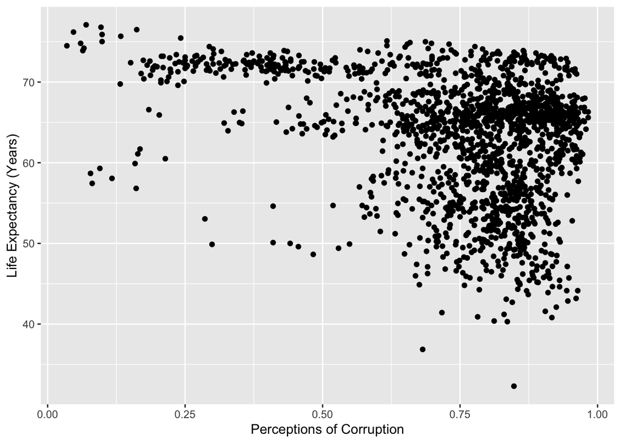

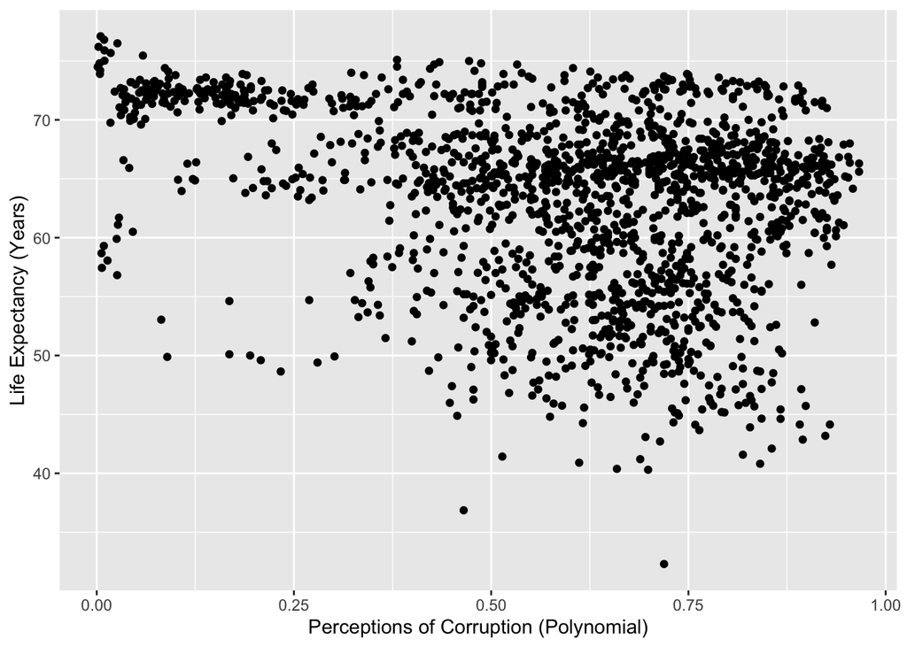

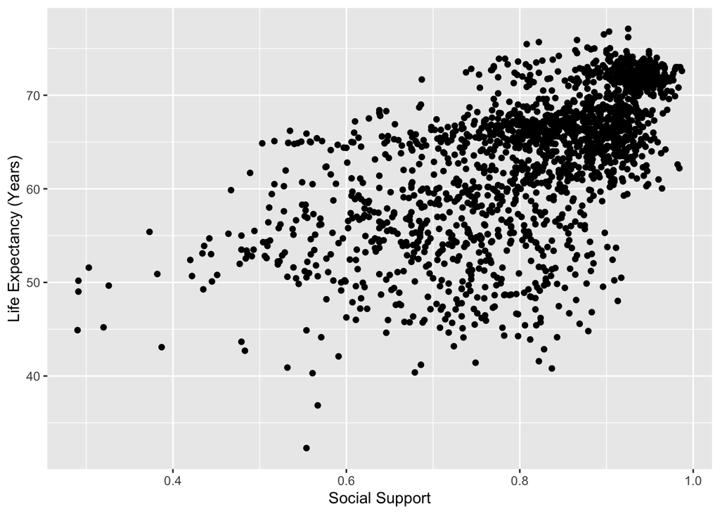

````markdown
```{r}
#| label: exploratory-plots
#| warning: false
#| layout-nrow: 1

whr %>%
  ggplot(mapping = aes(x = perceptions_of_corruption, y = healthy_life_expectancy)) +
  geom_point() +
  labs(x = "Perceptions of Corruption",
       y = "Life Expectancy (Years)")

whr %>%
  ggplot(mapping = aes(x = perceptions_of_corruption^2, y = healthy_life_expectancy)) +
  geom_point() +
  labs(x = "Perceptions of Corruption (Polynomial)",
       y = "Life Expectancy (Years)")

whr %>%
  ggplot(mapping = aes(x = social_support, y = healthy_life_expectancy)) +
  geom_point() +
  labs(x = "Social Support",
       y = "Life Expectancy (Years)")
```
````

I then add variables to the model one by one, checking the R-squared at each fit. When the R-squared changes hugely (e.g., over 5%), I keep the variable. When it changes only a little (e.g., 1%), I use cross-validation to see if the improvement is just overfitting or if it is actually meaningful.

## Part 2: Three Candidates

8. Choose the three best candidate models among those you tried.

````markdown
```{r}
#| label: top-candidates

whr_rec_1 <- recipe(healthy_life_expectancy ~
                      log_gdp_per_capita +
                      social_support +
                      freedom_to_make_life_choices +
                      year +
                      perceptions_of_corruption,
                    data = whr)

whr_rec_2 <- whr_rec_1 %>%
  step_naomit(perceptions_of_corruption, skip = TRUE) %>%
  step_poly(perceptions_of_corruption, degree = 2)

whr_rec_3 <- recipe(healthy_life_expectancy ~
                      log_gdp_per_capita +
                      social_support +
                      freedom_to_make_life_choices +
                      year,
                    data = whr)
```
````

Top 3 models:

**Model 1:** `log_gdp_per_capita`, `social_support`, `freedom_to_make_life_choices`, `year`, `perceptions_of_corruption` (all variables except `generosity` and `regional_indicator`)

**Model 2:** Same as model 1, but removing the missing values from `perceptions_of_corruption` and using a quadratic term for `perceptions_of_corruption`.

**Model 3:** `log_gdp_per_capita`, `social_support`, `freedom_to_make_life_choices`, `year` (removing `perceptions_of_corruption`)

9. Supply your code and results for comparing these models, and discuss how you decided which *one* model was the best one.

````markdown
```{r}
#| label: cv
whr_cv <- vfold_cv(whr, v = 5)
```
````

Top 3 models:

**Model 1:** `log_gdp_per_capita`, `social_support`, `freedom_to_make_life_choices`, `year`, `perceptions_of_corruption` (all variables but `generosity` and `regional_indicator`)

````markdown
```{r}
#| label: model1-metrics

workflow() %>%
  add_model(lin_mod) %>%
  add_recipe(whr_rec_1) %>%
  fit_resamples(whr_cv) %>%
  collect_metrics()
```
````

```
# A tibble: 2 × 6
  .metric .estimator  mean     n std_err .config
  <chr>   <chr>      <dbl> <int>   <dbl> <chr>
1 rmse    standard   3.82      5  0.105  Preprocessor1_Model1
2 rsq     standard   0.752     5  0.0112 Preprocessor1_Model1
```

**Model 2:** Same as model 1, but removing the missing values from `perceptions_of_corruption` and using a quadratic term for `perceptions_of_corruption`.

````markdown
```{r}
#| label: model2-metrics

workflow() %>%
  add_model(lin_mod) %>%
  add_recipe(whr_rec_2) %>%
  fit_resamples(whr_cv) %>%
  collect_metrics()
```
````

```
# A tibble: 2 × 6
  .metric .estimator  mean     n std_err .config
  <chr>   <chr>      <dbl> <int>   <dbl> <chr>
1 rmse    standard   3.82      5  0.106  Preprocessor1_Model1
2 rsq     standard   0.752     5  0.0112 Preprocessor1_Model1
```

**Model 3:** `log_gdp_per_capita`, `social_support`, `freedom_to_make_life_choices`, `year` (removing `perceptions_of_corruption`)

````markdown
```{r}
#| label: model3-metrics

workflow() %>%
  add_model(lin_mod) %>%
  add_recipe(whr_rec_3) %>%
  fit_resamples(whr_cv) %>%
  collect_metrics()
```
````

```
# A tibble: 2 × 6
  .metric .estimator  mean     n std_err .config
  <chr>   <chr>      <dbl> <int>   <dbl> <chr>
1 rmse    standard   3.89      5  0.0838 Preprocessor1_Model1
2 rsq     standard   0.736     5  0.0102 Preprocessor1_Model1
```

Based on the above, the best model is the one that **does** include perceptions of corruption. It’s almost exactly the same whether we square or not, so for simplicity, we’ll use the non-polynomial model.

## Part 3: Final Model

10. Summarize the results from your final model. Don’t forget to fit your final model on the **full** dataset, even if you used *test / training* data or *cross-validation* during the model selection process.

````markdown
```{r}
#| label: final-model-fit

whr_final <- workflow() %>%
  add_model(lin_mod) %>%
  add_recipe(whr_rec_1) %>%
  fit(whr)

extract_fit_parsnip(whr_final) %>%
  broom::glance()
```
````

```
# A tibble: 1 × 12
  r.squared adj.r.squared sigma statistic p.value    df logLik   AIC   BIC
      <dbl>         <dbl> <dbl>     <dbl>   <dbl> <dbl>  <dbl> <dbl> <dbl>
1     0.753         0.752  3.82     1013.       0     5 -4601. 9215. 9253.
# ℹ 3 more variables: deviance <dbl>, df.residual <int>, nobs <int>
```

We are able to explain about 75% of the variability in life expectancy with these five measures.

11. Include a plot of the residuals and discussion of what you see, and interpretations of the coefficients and metrics.

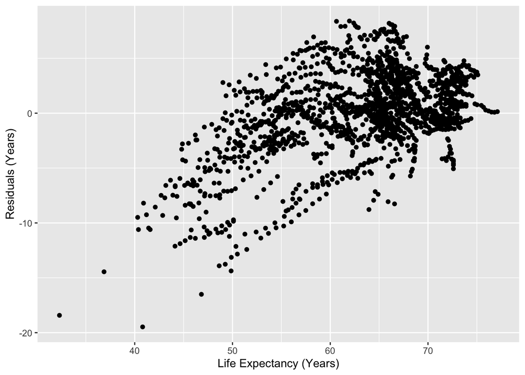

````markdown
```{r}
#| label: residual-plot
#| warning: false

whr %>%
  mutate(
    preds = predict(whr_final, new_data = whr)$.pred,
    resids = healthy_life_expectancy - preds
  ) %>%
  ggplot(mapping = aes(x = healthy_life_expectancy, y = resids)) +
  geom_point() +
  labs(x = "Life Expectancy (Years)",
       y = "Residuals (Years)")
```
````

# Predicting Life Expectancy – K-Nearest-Neighbors

Now we will find the best KNN model for predicting life expectancy.

Consider only the three top candidate models from **Q8**.

## Part 1: Tuning K

12. For **each** of your top three candidate models (from Q8), find the best choice of **K**. Show all your work, and provide a brief summary at the end (e.g., “For Model 1, we choose a K of [something] because [reasons]. For Model 2, …”)

````markdown
```{r}
#| label: k-grid
whr_clean <- whr %>%
  drop_na()

whr_cv_clean <- vfold_cv(whr_clean, v = 5)

knn_spec_tune <- nearest_neighbor(neighbors = tune()) %>%
  set_mode("regression") %>%
  set_engine("kknn")

k_grid <- grid_regular(neighbors(c(2, 20)),
                       levels = 5)
```
````

**Model 1**

````markdown
```{r}
#| label: tune-model1

tune_1 <- workflow() %>%
  add_model(knn_spec_tune) %>%
  add_recipe(whr_rec_1) %>%
  tune_grid(
    resamples = whr_cv_clean,
    grid = k_grid
  ) %>%
  collect_metrics()

tune_1 %>%
  group_by(.metric) %>%
  arrange(desc(mean))
```
````

```
# A tibble: 10 × 7
# Groups:   .metric [2]
   neighbors .metric .estimator  mean     n std_err .config
       <int> <chr>   <chr>      <dbl> <int>   <dbl> <chr>
 1         2 rmse    standard   4.14      5  0.0714 Preprocessor1_Model1
 2         6 rmse    standard   3.64      5  0.0640 Preprocessor1_Model2
 3        20 rmse    standard   3.59      5  0.0989 Preprocessor1_Model5
 4        15 rmse    standard   3.56      5  0.0933 Preprocessor1_Model4
 5        11 rmse    standard   3.55      5  0.0840 Preprocessor1_Model3
 6        11 rsq     standard   0.783     5  0.0106 Preprocessor1_Model3
 7        15 rsq     standard   0.782     5  0.0108 Preprocessor1_Model4
 8        20 rsq     standard   0.780     5  0.0112 Preprocessor1_Model5
 9         6 rsq     standard   0.772     5  0.0115 Preprocessor1_Model2
10         2 rsq     standard   0.717     5  0.0161 Preprocessor1_Model1
```

Lowest RMSE and highest R-squared occurs at k = 11, but k = 15 is only 0.01 off of these values.

**Model 2**

````markdown
```{r}
#| label: tune-model2

tune_2 <- workflow() %>%
  add_model(knn_spec_tune) %>%
  add_recipe(whr_rec_2) %>%
  tune_grid(
    resamples = whr_cv_clean,
    grid = k_grid
  ) %>%
  collect_metrics()

tune_2 %>%
  group_by(.metric) %>%
  arrange(desc(mean))
```
````

```
# A tibble: 10 × 7
# Groups:   .metric [2]
   neighbors .metric .estimator  mean     n std_err .config
       <int> <chr>   <chr>      <dbl> <int>   <dbl> <chr>
 1         2 rmse    standard   4.18      5 0.0550  Preprocessor1_Model1
 2         6 rmse    standard   3.69      5 0.0579  Preprocessor1_Model2
 3        20 rmse    standard   3.61      5 0.0968  Preprocessor1_Model5
 4        11 rmse    standard   3.59      5 0.0848  Preprocessor1_Model3
 5        15 rmse    standard   3.59      5 0.0929  Preprocessor1_Model4
 6        15 rsq     standard   0.780     5 0.0109  Preprocessor1_Model4
 7        11 rsq     standard   0.779     5 0.00990 Preprocessor1_Model3
 8        20 rsq     standard   0.778     5 0.0116  Preprocessor1_Model5
 9         6 rsq     standard   0.767     5 0.0103  Preprocessor1_Model2
10         2 rsq     standard   0.711     5 0.0144  Preprocessor1_Model1
```

The lowest RMSE is tied at k = 11 and k = 15. While the highest R-squared occurs at k = 15, this is only 0.001 better than k = 11.

**Model 3**

````markdown
```{r}
#| label: tune-model3

tune_3 <- workflow() %>%
  add_model(knn_spec_tune) %>%
  add_recipe(whr_rec_3) %>%
  tune_grid(
    resamples = whr_cv_clean,
    grid = k_grid
  ) %>%
  collect_metrics()

tune_3 %>%
  group_by(.metric) %>%
  arrange(desc(mean))
```
````

```
# A tibble: 10 × 7
# Groups:   .metric [2]
   neighbors .metric .estimator  mean     n std_err .config
       <int> <chr>   <chr>      <dbl> <int>   <dbl> <chr>
 1         2 rmse    standard   4.24      5  0.116  Preprocessor1_Model1
 2         6 rmse    standard   3.76      5  0.0869 Preprocessor1_Model2
 3        11 rmse    standard   3.67      5  0.0814 Preprocessor1_Model3
 4        20 rmse    standard   3.67      5  0.0972 Preprocessor1_Model5
 5        15 rmse    standard   3.66      5  0.0871 Preprocessor1_Model4
 6        15 rsq     standard   0.770     5  0.0105 Preprocessor1_Model4
 7        20 rsq     standard   0.770     5  0.0112 Preprocessor1_Model5
 8        11 rsq     standard   0.769     5  0.0107 Preprocessor1_Model3
 9         6 rsq     standard   0.757     5  0.0135 Preprocessor1_Model2
10         2 rsq     standard   0.702     5  0.0199 Preprocessor1_Model1
```

Lowest RMSE and highest R-squared occurs at k = 15, but these values are practically tied with the RMSE and R-squared at k = 11 and k = 20.

Among these three, Model 1 again has the best performance, but the closeness of the results from k = 11 and k = 15 warrant us checking the range of k more closely.

#### Q2: Best model

Fit and report your single best model from Q1.

You should include:

- An argument for your choice of K, including a plot.
- A plot of the residuals

```
# A tibble: 16 × 7
# Groups:   .metric [2]
   neighbors .metric .estimator  mean     n std_err .config
       <int> <chr>   <chr>      <dbl> <int>   <dbl> <chr>
 1        19 rmse    standard   3.58      5  0.0984 Preprocessor1_Model8
 2        17 rmse    standard   3.57      5  0.0967 Preprocessor1_Model7
 3        16 rmse    standard   3.57      5  0.0953 Preprocessor1_Model6
 4        15 rmse    standard   3.56      5  0.0933 Preprocessor1_Model5
 5        14 rmse    standard   3.56      5  0.0909 Preprocessor1_Model4
 6        13 rmse    standard   3.55      5  0.0888 Preprocessor1_Model3
 7        11 rmse    standard   3.55      5  0.0840 Preprocessor1_Model1
 8        12 rmse    standard   3.55      5  0.0867 Preprocessor1_Model2
 9        12 rsq     standard   0.783     5  0.0106 Preprocessor1_Model2
10        13 rsq     standard   0.783     5  0.0106 Preprocessor1_Model3
11        14 rsq     standard   0.783     5  0.0107 Preprocessor1_Model4
12        11 rsq     standard   0.783     5  0.0106 Preprocessor1_Model1
13        15 rsq     standard   0.782     5  0.0108 Preprocessor1_Model5
14        16 rsq     standard   0.782     5  0.0110 Preprocessor1_Model6
15        17 rsq     standard   0.781     5  0.0111 Preprocessor1_Model7
16        19 rsq     standard   0.780     5  0.0112 Preprocessor1_Model8
```

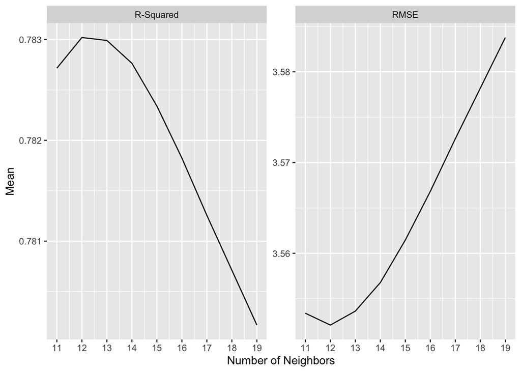

````markdown
```{r}
#| label: knn-finer-grid

k_grid_finer <- grid_regular(neighbors(c(11, 19)),
                             levels = 8)

tune_final <- workflow() %>%
  add_model(knn_spec_tune) %>%
  add_recipe(whr_rec_1) %>%
  tune_grid(
    resamples = whr_cv_clean,
    grid = k_grid_finer
  ) %>%
  collect_metrics()

tune_final %>%
  group_by(.metric) %>%
  arrange(desc(mean))

tune_final %>%
  mutate(.metric = if_else(.metric == "rsq",
                           "R-Squared",
                           "RMSE")
         ) %>%
  ggplot(mapping = aes(x = neighbors, y = mean)) +
  geom_line() +
  scale_x_continuous(limits = c(11, 19), breaks = seq(11, 19, by = 1)) +
  facet_wrap(~.metric, scales = "free") +
  labs(x = "Number of Neighbors",
       y = "Mean")
```
````

Highest R-squared is at 12. Lowest RMSE is at 12. So, let’s go with 12!

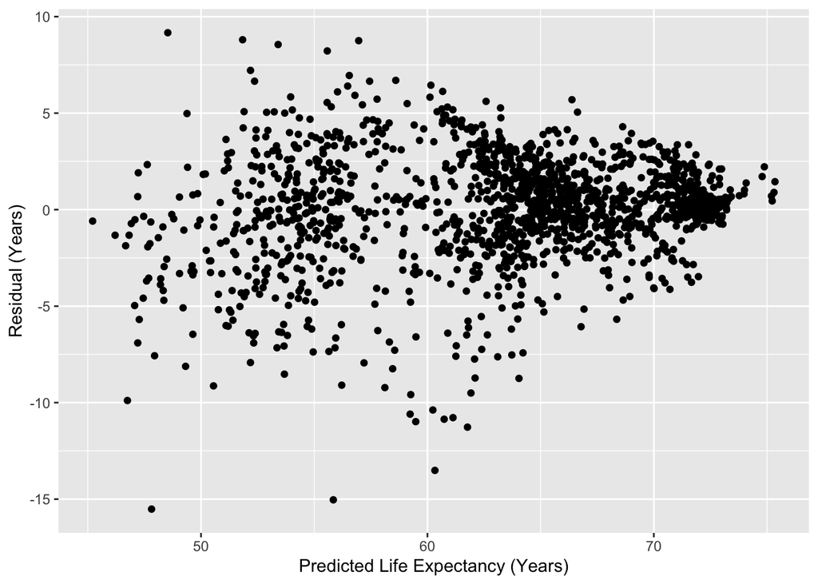

````markdown
```{r}
knn_spec <- nearest_neighbor(neighbors = 12) %>%
  set_mode("regression") %>%
  set_engine("kknn")

final_knn <- workflow() %>%
  add_model(knn_spec) %>%
  add_recipe(whr_rec_1) %>%
  fit(whr_clean)

whr_clean %>%
  mutate(
    preds = predict(final_knn, whr_clean)$.pred,
    resids = healthy_life_expectancy - preds
  ) %>%
  ggplot(aes(x = preds, y = resids)) +
  geom_point() +
  labs(x = "Predicted Life Expectancy (Years)",
       y = "Residual (Years)")
```
````

These residuals looks pretty good! They are around 0 and not strongly patterned.

If we want to get fancy, there’s some concern about heteroskedacisity, since it seems that the spread of the residuals gets smaller as the life expectancy gets larger. However, this only matters in linear models.

# Predicting on New Data

The following code will load up a dataset of the World Happiness Report from 2021, pertaining to happiness measurements in the year 2020. We sometimes call this new data - that was not involved in the **cross-validation** process or in the final model fitting - the **validation** set. It is the “Ultimate” test set, that only gets to be used once ever.

````markdown
```{r}
#| label: load-validation-data
#| message: false

whr_new <- read_csv(here::here("02-CV-KNN",
                               "Assignment",
                               "data",
                               "whr_2020.csv")
                    )
```
````

14. Use your **one** best *least-squares regression* model (Q9) to predict the life expectancy of all countries.

````markdown
```{r}
#| label: predict-ls-on-validation

final_mod_ls <- workflow() %>%
  add_model(lin_mod) %>%
  add_recipe(whr_rec_1) %>%
  fit(whr)

whr_new <- whr_new %>%
  mutate(
    preds_ls = predict(final_mod_ls, new_data = whr_new)$.pred
  )

whr_new %>%
  rmse(
    truth = healthy_life_expectancy,
    estimate = preds_ls
  )
```
````

```
# A tibble: 1 × 3
  .metric .estimator .estimate
  <chr>   <chr>          <dbl>
1 rmse    standard        3.46
```

15. Use your **one** best *KNN* model (Q13) to predict the life expectancy of all countries.

````markdown
```{r}
#| label: predict-knn-on-validation

final_mod_knn <- workflow() %>%
  add_model(knn_spec) %>%
  add_recipe(whr_rec_1) %>%
  fit(whr)

whr_new <- whr_new %>%
  mutate(
    preds_knn = predict(final_mod_knn, new_data = whr_new)$.pred
  )

whr_new %>%
  rmse(
    truth = healthy_life_expectancy,
    estimate = preds_knn
  )
```
````

```
# A tibble: 1 × 3
  .metric .estimator .estimate
  <chr>   <chr>          <dbl>
1 rmse    standard        2.56
```

16. Which model did a better job predicting the true values in the new data?

The KNN model k = 12 was the overall winner!

# Part Five: Discussion Questions

For these questions, you do **not** have to actually perform any of the computations described. However, if the conceptual answer is not obvious to you, it may help to do so!

### Parametric and Non-Parametric

17. Make an argument for why a **parametric** method, like least-squares regression, might be preferred in this task.

If we are trying to understand what factors drive a country’s life expectancy, so that we can implement policy to improve well-being, the parametric model will be better. We’ll be able to interpret the coefficients as measures of the relationship between predictors and response.

18. Then make an argument for why a **non-parametric** method, like K-Nearest-Neighbors, might be preferred.

If we are trying to use current information to accurately predict the life expectancy next year in a particular country, it may be that a non-parametric method performs better.

## Interpretation and Prediction

19. If your only goal were **interpretation**, which of the candidate models (from *any* section of the assignment) would you have chosen? Why?

I would choose the linear model without the polynomial term, because transformed variables are harder to interpret and parametric methods are better for interpretation.

20. If your only goal were **prediction** on future data, which of the candidate models would you have chosen? Why?

In this case, I would choose KNN with K = 12, since it had the lowest MSE on the validation set and in cross-validation studies.

## Standardization

21. Consider your final best least-squares regression model from Q9. Suppose we fit this model again, but this time, we normalize **all** of the quantitative variables. Will anything change? Give a (conceptual) argument for why this is true.

The coefficients will change, because when you normalize, you change the scale of the values of the predictors.

However, the significance of the coefficients and the performance of the model will not change, because you are not meaningfully changing the model assumptions in any way.

## Quantitative or Categorical?

In Part One, Q1, you discovered that (spoiler alert!) the `year` variable did **not** have a linear relationship with the `happiness_score`, but that when we treated `year` as categorical, it did have some relationship.

22. Suppose we add the predictor `year` to our final model as a **categorical variable** and fit the model on all the data. Then, we use this new model to predict on the 2020 data. What is wrong with this plan?

If “year” is a categorical variable, we expect future data to be limited to the known categories. But 2020 is not a category in the data up through 2019!